# Occupation Epidemiology

Hengyan

2026-03-08

# Introduction

## Occupational Health Aims

1. Establishing the causes and determinants of work-related disease.
2. Ensuring adequate recognition and quantification of work-related disease. Determining appropriate occupational exposure limits.
3. Providing evidence for policy-makers

## Benefits for workers

1. Reduction of work-related health risks, e.g., by reducing exposure levels.
2. Elimination/substitution of hazards.
3. Prevention
4. Compensation (through recognition as an occupational disease)

## Benefits for society

1. Reduction of environmental health risks
2. Derivation and application of exposure limits 3.Reduction of the economic burden of work-related disease

### Work and Health: Psychosocial Conditions

1. Demand-Control model - Karasek 1979

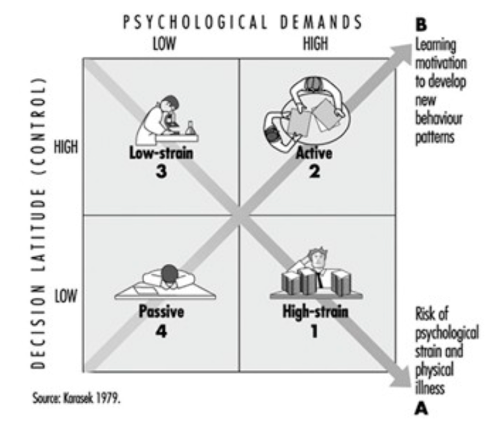

2. Effort-Reward Imbalance model - Siegrist 1996

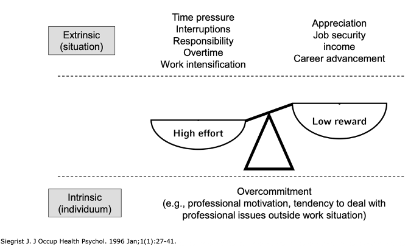

3. Job-Demands-Resources model - Demerouti 2001

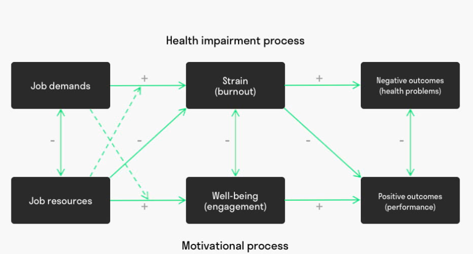

## Precarious Work & Health

1. Precarious work is a multidimensional construct that includes employment insecurity, income inadequacy, and lack of rights and protection in the workplace.
2. Precarious work is associated with a range of adverse health outcomes, including mental disorders, cardiovascular diseases, and musculoskeletal disorders.
3. The mechanisms linking precarious work to health outcomes are complex and may include stress, lack of social support, and exposure to hazardous working conditions.
4. Interventions to reduce precarious work and improve working conditions may have significant benefits for worker health and well-being.

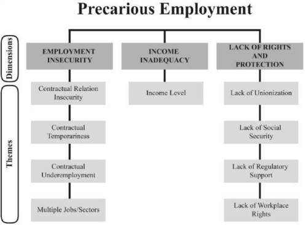